# Gender bias in audience of seminars and career position

# Data

Data description and summary statitiscs in script `0_data_summary`.

```r
load("data_clean/data_audience.Rdata")
data <- data_a
```

# Modeling

The audience (number of attendants in the seminar) is modeled by the gender (male, female), the academic level (student, postdoc, professor) of the speaker, and affirmative actions (before, after).

Negative binomial mixed-effects model with year as random intercept.

```r
mg0 <- glmmTMB(audience_n~ 1 + (1|year), data=data, family= nbinom2)
mg1 <- glmmTMB(audience_n~ gender + (1|year), data=data, family= nbinom2)
mg2 <- glmmTMB(audience_n~ position_cat + (1|year), data=data, family= nbinom2)
mg3 <- glmmTMB(audience_n~ affirm_action + (1|year), data=data, family= nbinom2)

mg4 <- glmmTMB(audience_n~ gender + position_cat + (1|year),
               data=data, family= nbinom2)
mg5 <- glmmTMB(audience_n~ gender + affirm_action + (1|year),
               data=data, family= nbinom2)
mg6 <- glmmTMB(audience_n~ affirm_action + position_cat+ (1|year),
               data=data, family= nbinom2)

mg7 <- glmmTMB(audience_n~ gender * position_cat+ (1|year),
               data=data, family= nbinom2)
mg8 <- glmmTMB(audience_n~ gender * affirm_action+ (1|year),
               data=data, family= nbinom2)
mg9 <- glmmTMB(audience_n~ affirm_action * position_cat+ (1|year),
               data=data, family= nbinom2)

mg10 <- glmmTMB(audience_n~ gender + position_cat + affirm_action + (1|year),
               data=data, family= nbinom2)
mg11 <- glmmTMB(audience_n~ gender * position_cat + affirm_action + (1|year),
               data=data, family= nbinom2)
mg12 <- glmmTMB(audience_n~ gender + position_cat * affirm_action + (1|year),
               data=data, family= nbinom2)

mg13 <- glmmTMB(audience_n~ gender * position_cat * affirm_action + (1|year),
               data=data, family= nbinom2)

AICtab(mg0,mg1,mg2, mg3, mg4,mg5,mg6,mg7,mg8,mg9,mg10,mg11,mg12,mg13, base=T,
       weights=T) %>%
  kable(digits=2)
```

|  | AIC | dAIC | df | weight |
| --- | --- | --- | --- | --- |
| mg11 | 2160.03 | 0.00 | 9 | 0.45 |
| mg10 | 2161.43 | 1.41 | 7 | 0.22 |
| mg7 | 2162.27 | 2.24 | 8 | 0.15 |
| mg4 | 2163.49 | 3.47 | 6 | 0.08 |
| mg12 | 2163.98 | 3.95 | 9 | 0.06 |
| mg13 | 2166.62 | 6.59 | 14 | 0.02 |
| mg6 | 2167.07 | 7.04 | 6 | 0.01 |
| mg2 | 2168.86 | 8.83 | 5 | 0.01 |
| mg9 | 2170.27 | 10.25 | 8 | 0.00 |
| mg5 | 2185.83 | 25.80 | 5 | 0.00 |
| mg1 | 2186.24 | 26.22 | 4 | 0.00 |
| mg8 | 2187.65 | 27.62 | 6 | 0.00 |
| mg0 | 2201.16 | 41.14 | 3 | 0.00 |
| mg3 | 2201.29 | 41.27 | 4 | 0.00 |

## Residual diagnostic

Using the `DHARMa` package.

The two most plausible models presented a satisfactory residual diagnostic.

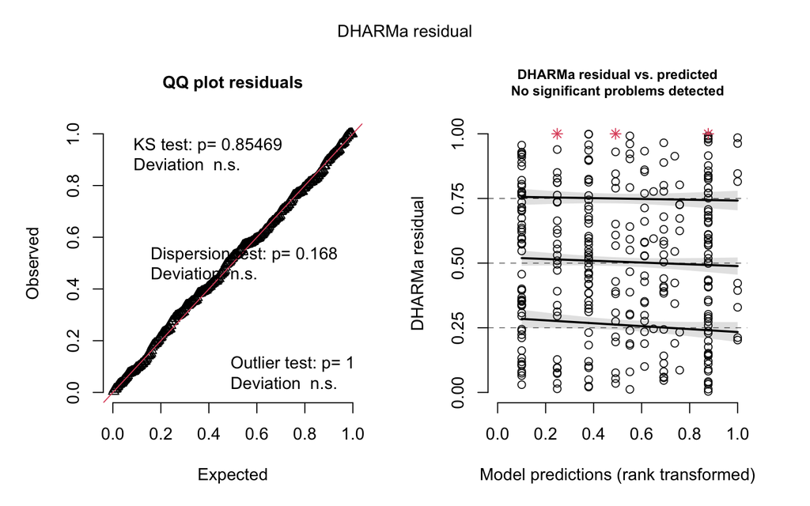

```r
plot(simulateResiduals(mg11))
```

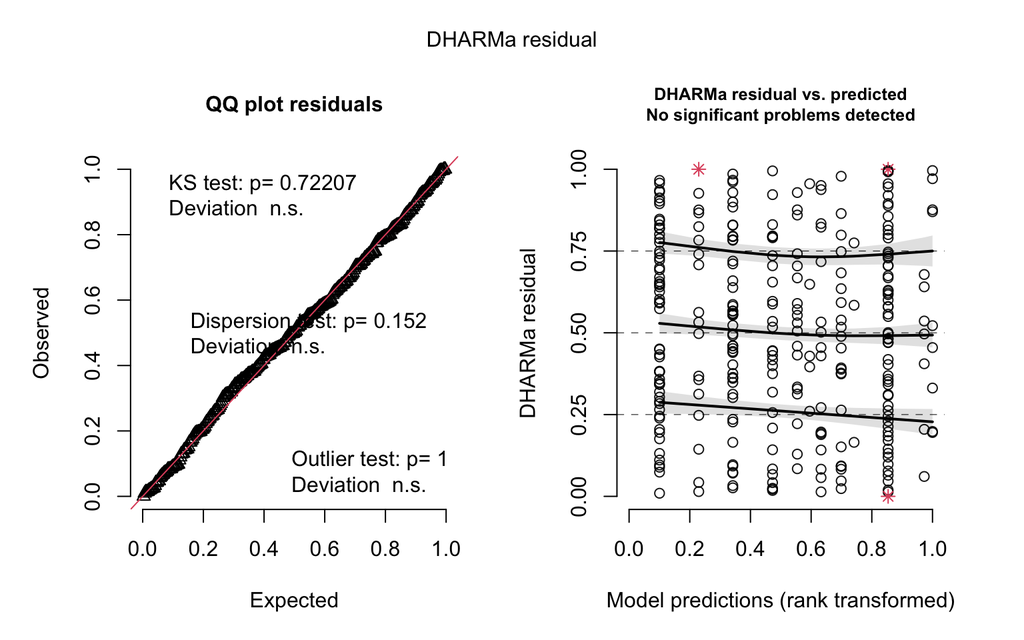

```r
plot(simulateResiduals(mg10))
```

## Models result

The two equally plausible models for the audience included gender, academic level and affirmative actions as predictors, with the difference that the best fitted model includes an interaction of gender and academic level.

```r
summary(mg11)
```

```
##  Family: nbinom2  ( log )
## Formula:          audience_n ~ gender * position_cat + affirm_action + (1 | year)
## Data: data
##
##      AIC      BIC   logLik deviance df.resid
##   2160.0   2193.3  -1071.0   2142.0      289
##
## Random effects:
##
## Conditional model:
##  Groups Name        Variance Std.Dev.
##  year   (Intercept) 0.009051 0.09513
## Number of obs: 298, groups:  year, 12
##
## Dispersion parameter for nbinom2 family (): 7.05
##
## Conditional model:
##                               Estimate Std. Error z value Pr(>|z|)
## (Intercept)                    2.80057    0.06192   45.23   <2e-16 ***
## genderM                        0.11642    0.07417    1.57   0.1165
## position_catpostdoc            0.12249    0.10663    1.15   0.2506
## position_catprofessor          0.16594    0.10469    1.59   0.1130
## affirm_actionafter             0.21633    0.09697    2.23   0.0257 *
## genderM:position_catpostdoc   -0.12984    0.14357   -0.90   0.3658
## genderM:position_catprofessor  0.22663    0.12674    1.79   0.0738 .
## ---
## Signif. codes:  0 '***' 0.001 '**' 0.01 '*' 0.05 '.' 0.1 ' ' 1
```

```r
performance::r2(mg11)
```

```
## # R2 for Mixed Models
##
##   Conditional R2: 0.221
##      Marginal R2: 0.181
```

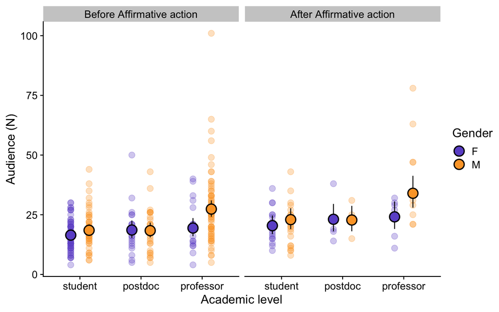

```r
myg11 <- ggpredict(mg11, terms=c("position_cat","gender", "affirm_action"))
prs <- as.data.frame(myg11) %>% rename(affirm_action = facet)
colnames(prs)[1] <- "position_cat"
```

```r
summary(mg10)
```

```
##  Family: nbinom2  ( log )
## Formula:          audience_n ~ gender + position_cat + affirm_action + (1 | year)
## Data: data
##
##      AIC      BIC   logLik deviance df.resid
##   2161.4   2187.3  -1073.7   2147.4      291
##
## Random effects:
##
## Conditional model:
##  Groups Name        Variance Std.Dev.
##  year   (Intercept) 0.008642 0.09296
## Number of obs: 298, groups:  year, 12
##
## Dispersion parameter for nbinom2 family (): 6.87
##
## Conditional model:
##                       Estimate Std. Error z value Pr(>|z|)
## (Intercept)            2.78546    0.05768   48.29  < 2e-16 ***
## genderM                0.15395    0.05522    2.79   0.0053 **
## position_catpostdoc    0.04292    0.07173    0.60   0.5496
## position_catprofessor  0.33054    0.06264    5.28 1.32e-07 ***
## affirm_actionafter     0.20807    0.09577    2.17   0.0298 *
## ---
## Signif. codes:  0 '***' 0.001 '**' 0.01 '*' 0.05 '.' 0.1 ' ' 1
```

```r
performance::r2(mg10)
```

```
## # R2 for Mixed Models
##
##   Conditional R2: 0.208
##      Marginal R2: 0.169
```

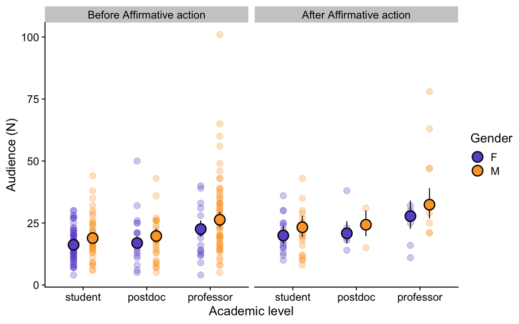

```r
myg10 <- ggpredict(mg10, terms=c("position_cat","gender", "affirm_action"))
pr10 <- as.data.frame(myg10) %>% rename(affirm_action = facet)
colnames(pr10)[1] <- "position_cat"
```

# Only professors - productivity metrics

Investigating if differences in productivity between male and female professors and researches are related to the audience.

We measured productivity publication metrics from Google Scholar for professors and researchers.

Creating productivity index using PCA 1st axis from metrics.

## PCA productivity metrics

```r
dp <- data %>% filter(!is.na(data$total_citation_n),
                      !is.na(data$nature_index_count))
colnames(dp)[22:29] <- c("tot_cit", "h", "i10", "most_cit", "cit_cum",
                        "career_Y", "nature_count", "nature_share")
table(dp$gender, dp$affirm_action)
```

```
##
##     before after
##   F     14     6
##   M     58     9
```

Productivity publication metrics

```r
pca1 <- PCA(dp[, c(22:29)], graph=F)
```

```r
p1 <- fviz_pca_biplot(pca1, col.ind = dp$gender, addEllipses=TRUE,
                      col.ind.sub="none",  geom="point",
                      repel = TRUE) +
  geom_vline(xintercept = 0, linetype="dashed") +
  geom_hline(yintercept = 0, linetype="dashed")+
  scale_color_manual(name="Gender",values = c("#6D57CF","#FCA532"))+
  scale_shape(name="Gender")+
  scale_fill_manual(name="Gender",values = c("#6D57CF","#FCA532"))+
  ggtitle("Productivity metrics") +
  xlab("PC1 (52%)") + ylab("PC2 (21%)") +
  theme_cowplot()

p1
#("figures/pca_biplot.jpeg", width=6, height = 6)
```

[output not shown]

Extracting PCA 2 first axes

```r
dp$pc1 <- pca1$ind$coord[,1]
dp$pc2 <- pca1$ind$coord[,2]
```

## Modeling

```r
m0 <- glmmTMB(audience_n ~ 1 + affirm_action + (1|year), data=dp, family=nbinom2)
m1 <- glmmTMB(audience_n ~ gender + affirm_action +(1|year), data=dp,
              family=nbinom2)
m2 <- glmmTMB(audience_n ~ pc1  + affirm_action + (1|year), data=dp,
              family=nbinom2)
m3 <- glmmTMB(audience_n ~ gender + pc1 + affirm_action + (1|year),
              data=dp, family=nbinom2)
m4 <- glmmTMB(audience_n ~ gender*pc1 + affirm_action + (1|year),
              data=dp, family=nbinom2)

AICtab(m0,m1,m2,m3,m4,
       base=T, weights=T) %>% kable(digits=2)
```

|  | AIC | dAIC | df | weight |
| --- | --- | --- | --- | --- |
| m3 | 691.32 | 0.00 | 6 | 0.60 |
| m4 | 692.95 | 1.64 | 7 | 0.27 |
| m2 | 695.04 | 3.73 | 5 | 0.09 |
| m1 | 696.94 | 5.62 | 5 | 0.04 |
| m0 | 702.13 | 10.82 | 4 | 0.00 |

## Residual diagnostic

Using the `DHARMa` package.

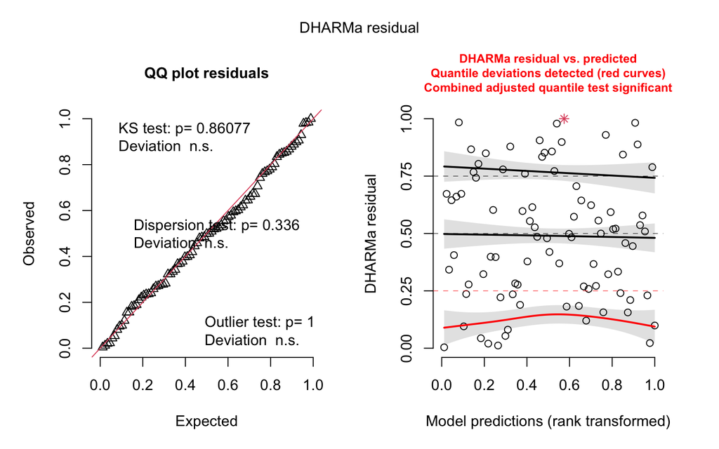

```r
plot(simulateResiduals(m3))
```

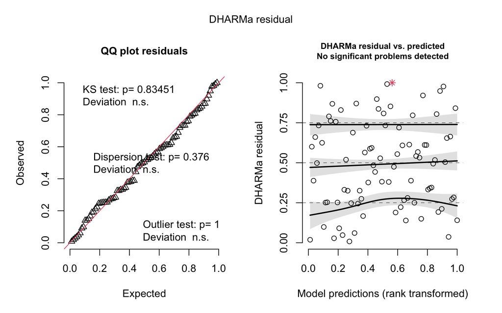

```r
plot(simulateResiduals(m4))
```

## Model results

```r
summary(m3)
```

```
##  Family: nbinom2  ( log )
## Formula:          audience_n ~ gender + pc1 + affirm_action + (1 | year)
## Data: dp
##
##      AIC      BIC   logLik deviance df.resid
##    691.3    706.1   -339.7    679.3       81
##
## Random effects:
##
## Conditional model:
##  Groups Name        Variance  Std.Dev.
##  year   (Intercept) 1.622e-09 4.027e-05
## Number of obs: 87, groups:  year, 11
##
## Dispersion parameter for nbinom2 family (): 5.52
##
## Conditional model:
##                    Estimate Std. Error z value Pr(>|z|)
## (Intercept)         3.03070    0.11415  26.550   <2e-16 ***
## genderM             0.30566    0.12366   2.472   0.0134 *
## pc1                 0.07246    0.02626   2.759   0.0058 **
## affirm_actionafter  0.27050    0.13267   2.039   0.0415 *
## ---
## Signif. codes:  0 '***' 0.001 '**' 0.01 '*' 0.05 '.' 0.1 ' ' 1
```

To calculate the R2 we used a negative binomial GLM without the year as random effect given problems with the function `r2` in package peformance. Given that the random intercepts have almost zero variance, the model without the random intercept didn’t change the model’s coefficients (neither the AIC and the model’s ranking results):

```r
m3b <- glm.nb(audience_n ~ gender + pc1 + affirm_action,
              data=dp)
performance::r2(m3b)
```

```
## # R2 for Generalized Linear Regression
##   Nagelkerke's R2: 0.278
```

We used the first PCA axis as predictors together with gender to explain the professor’s audience, and found that, as expected, audience increases with productivity index (first PCA axis) but female professors still presented on average audience *1.4* times smaller than male professors.

[figure not shown]

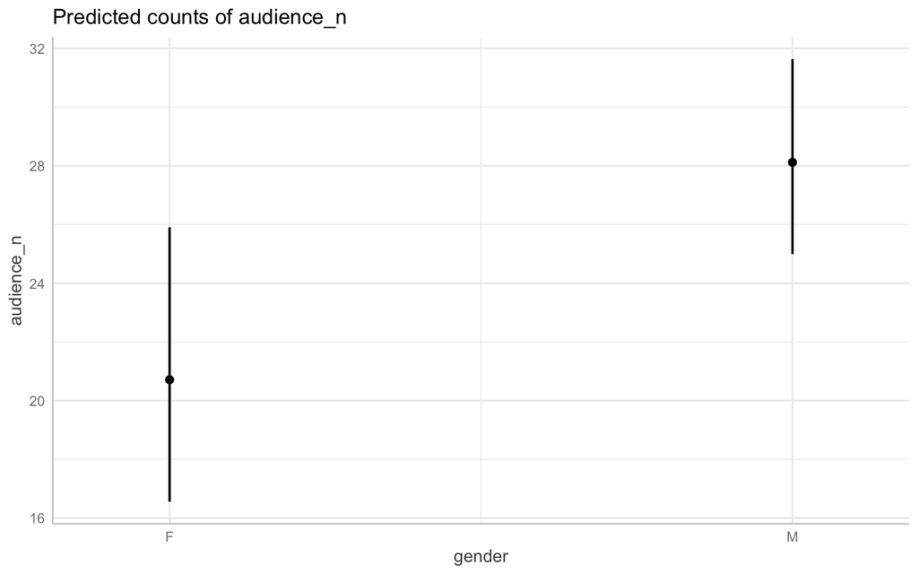

```r
my3 <- ggpredict(m3, terms=c("gender"))
plot(my3)
```

Second best-fitting model

```r
summary(m4)
```

```
##  Family: nbinom2  ( log )
## Formula:          audience_n ~ gender * pc1 + affirm_action + (1 | year)
## Data: dp
##
##      AIC      BIC   logLik deviance df.resid
##    693.0    710.2   -339.5    679.0       80
##
## Random effects:
##
## Conditional model:
##  Groups Name        Variance  Std.Dev.
##  year   (Intercept) 1.448e-09 3.805e-05
## Number of obs: 87, groups:  year, 11
##
## Dispersion parameter for nbinom2 family (): 5.54
##
## Conditional model:
##                    Estimate Std. Error z value Pr(>|z|)
## (Intercept)         3.04613    0.11750  25.925   <2e-16 ***
## genderM             0.29225    0.12621   2.316   0.0206 *
## pc1                 0.10209    0.05618   1.817   0.0692 .
## affirm_actionafter  0.26868    0.13243   2.029   0.0425 *
## genderM:pc1        -0.03813    0.06348  -0.601   0.5481
## ---
## Signif. codes:  0 '***' 0.001 '**' 0.01 '*' 0.05 '.' 0.1 ' ' 1
```

```r
m4b <- glm.nb(audience_n ~ gender * pc1 + affirm_action,
              data=dp)
performance::r2(m4b)
```

```
## # R2 for Generalized Linear Regression
##   Nagelkerke's R2: 0.283
```

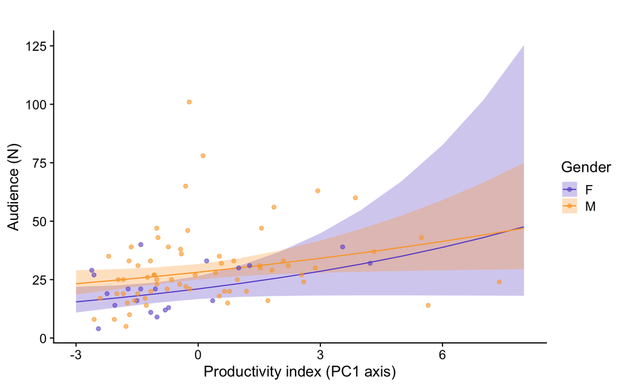

```r
my4 <- ggpredict(m4, terms=c("pc1","gender")) %>% as.data.frame()
ggplot(my4, aes(x=x, y=predicted, col=group)) +
  geom_ribbon(aes(ymin=conf.low,ymax=conf.high, fill=group), alpha=0.3,
             colour = NA) +
    geom_line()+
  scale_color_manual(name="Gender",values = c("#6D57CF","#FCA532"))+
  scale_fill_manual(name="Gender",values = c("#6D57CF","#FCA532"))+
   theme_cowplot() + ggtitle("") +
  ylab("Audience (N)") + xlab("Productivity index (PC1 axis)")+
  geom_point(data=dp, aes(x=pc1, y=audience_n, col=gender), alpha=0.6)
```

```r
#ggsave("figures/audience_professor.jpeg", width=9, height = 6)
```

# Figure 4 audience

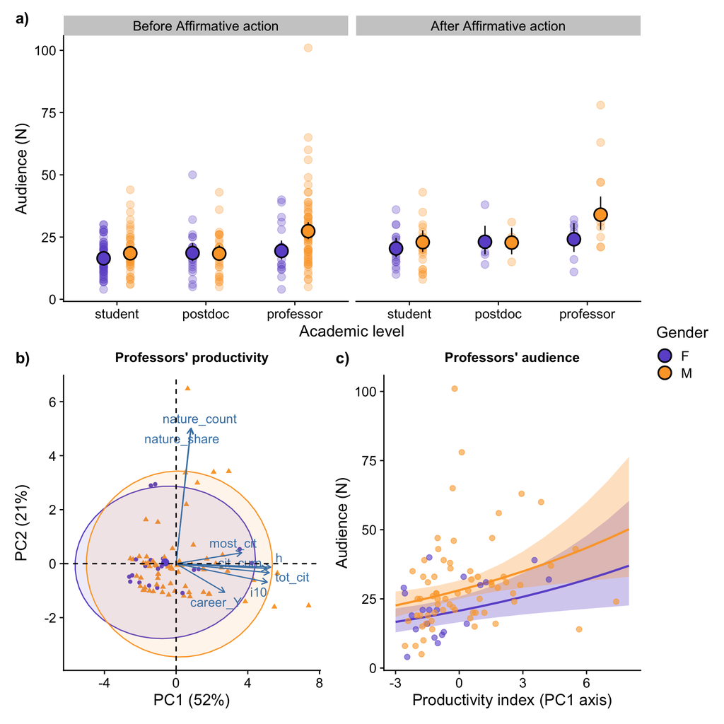